# Reproducable Research Project 1

born2rununix

June 11, 2015

# Reproducable Research - Project 1 Writeup

## ## Introduction

This document describes the analysis I performed for project 1 for the Coursera course “Reproducable Research”. All of the work was conducted in (http://www.rstudio.com) using open source packages/libraries. The document is written in a single R markdown file that can be processed by knitr and transformed into an HTML file.

## ## Data

The data for this assignment comes from course webpage and is provided from a personal activity monitoring device. This device collects data at 5 minute intervals throughout the day. The data covers a two month period from an anonymous individual collected during in 2012 over the months of October and November.

```r
# Load the dependencies
suppressWarnings(library(ggplot2))
suppressWarnings(library(caret))
suppressWarnings(library(Hmisc))
suppressWarnings(library(gridExtra))
suppressWarnings(library(dplyr))
# Supress warning messages and reduce the noise in the generated HTML for the writeup
options(warn=-1)
```

## ## Loading and Preprocessing the Data

The activity data set is downloaded from the URL provided on the course project page. The data sets contains date infromation and this is converted to an R DATE type to support the remaining analysis.

```r
# 1. Load the data (i.e. read.csv())
activityURL<-"https://d396qusza40orc.cloudfront.net/repdata%2Fdata%2Factivity.zip"

if ( ! file.exists('repdata_data_activity.zip')) {
  download.file(activityURL, 'repdata_data_activity.zip', method="curl")
  unzip('repdata_data_activity.zip')
} else {
  if ( ! file.exists('activity.csv') )
     unzip('repdata_data_activity.zip')
}

activity <- read.csv('activity.csv')
# 2. Transform the date to R data data type
activity$date <- as.Date(activity$date)
```

## ## What is mean total number of steps taken per day?

For this part of the assignment, the missing values in the dataset are ignored.

1. Calculate the total number of steps taken per day
2. Make a histogram of the total number of steps taken each day
3. Calculate and report the mean and median of the total number of steps taken per day

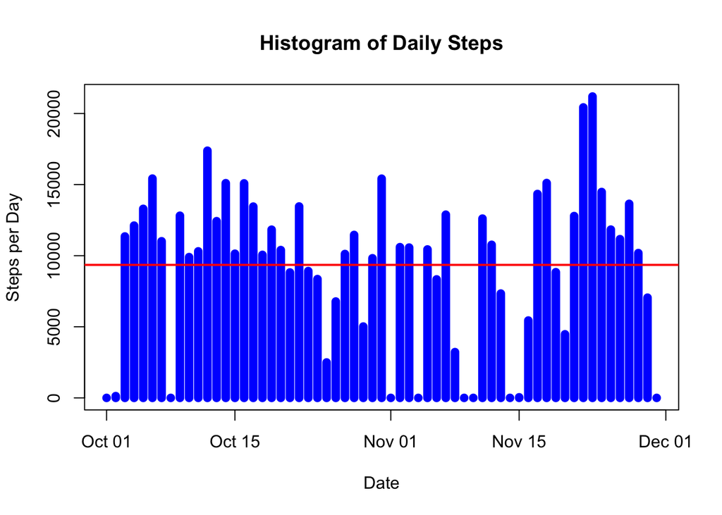

```r
# Calculate the total number of steps taken per day. Using tapply we sum the steps
# based on the date. We can also create a subset of the unique dates defined in the data set
# This provides equivalent X and Y parameters for the histogram.
total.steps <- tapply(activity$steps, activity$date, sum, na.rm=TRUE)
total.date = unique(activity$date)

# Make a histogram that shows the total number of steps taken per day
plot(total.date, total.steps, type="h",
     main="Histogram of Daily Steps", xlab="Date", ylab="Steps per Day", col="blue", lwd=8)
abline(h=mean(total.steps, na.rm=TRUE), col="red", lwd=2)
```

```r
# Calculate and report the mean and median of the total number of steps taken per day
paste("Mean Steps per Day =", mean(total.steps, na.rm=FALSE))
```

```
## [1] "Mean Steps per Day = 9354.22950819672"
```

```r
paste("Median Steps per Day =", median(total.steps, na.rm=FALSE))
```

```
## [1] "Median Steps per Day = 10395"
```

## ## What is the average daily activity pattern?

1. Make a time series plot (i.e. type = “l”) of the 5-minute interval (x-axis) and the average number of steps taken, averaged across all days (y-axis)
2. Which 5-minute interval, on average across all the days in the dataset, contains the maximum number of steps?

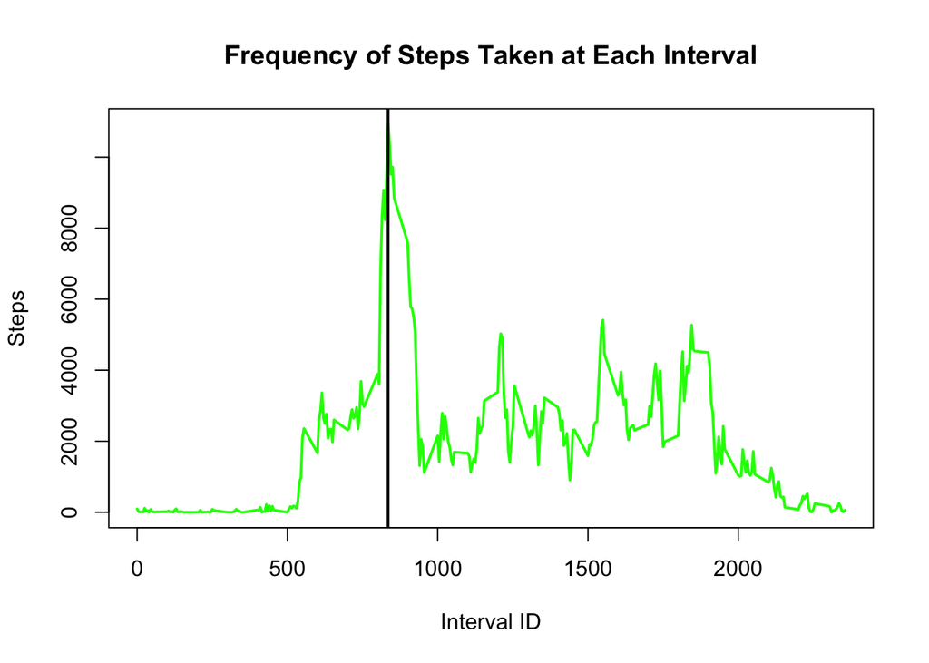

```r
# The time series plot requires the total number of steps per time interval, we calculate
# the total number of steps per 5 minute interval using tapply.
# We then calculate the mean number of steps for eachinterval.
interval.steps <- tapply(activity$steps, activity$interval, sum, na.rm=TRUE)
# calculate the mean number of steps for the given interval
mean.steps <- tapply(activity$steps, activity$interval, mean, na.rm=TRUE)

# 1. Make a time series plot (i.e. type = "l") of the 5-minute interval (x-axis) and the
#    average number of steps taken, averaged across all days (y-axis)
plot(unique(activity$interval), interval.steps, type="l",
     main="Frequency of Steps Taken at Each Interval",
     xlab="Interval ID", ylab="Steps", col="green", lwd=2)

# 2. Which 5-minute interval, on average across all the days in the dataset, contains
#    the maximum number of steps?
most <- activity$interval[which(mean.steps == max(mean.steps))]
# create a vertical line indicating the interval
abline(v=as.numeric(most), col="black", lwd=2)
```

```r
paste("Five minute interval containg maxmum number of steps =", most)
```

```
## [1] "Five minute interval containg maxmum number of steps = 835"
```

```r
paste("Maximum interval mean steps =", max(mean.steps))
```

```
## [1] "Maximum interval mean steps = 206.169811320755"
```

## ## Imputing missing values

Note that there are a number of days/intervals where there are missing values (coded as NA). The presence of missing days may introduce bias into some calculations or summaries of the data.

1. Calculate and report the total number of missing values in the dataset (i.e. the total number of rows with NAs)
2. Devise a strategy for filling in all of the missing values in the dataset. The strategy does not need to be sophisticated. For example, you could use the mean/median for that day, or the mean for that 5-minute interval, etc.
3. Create a new dataset that is equal to the original dataset but with the missing data filled in.
4. Make a histogram of the total number of steps taken each day and Calculate and report the mean and median total number of steps taken per day. Do these values differ from the estimates from the first part of the assignment? What is the impact of imputing missing data on the estimates of the total daily number of steps?

```r
# Calculate and report the total number of missing values in the dataset
paste("Total number of missing values in dataset =", sum(is.na(activity$steps)))
```

```
## [1] "Total number of missing values in dataset = 2304"
```

Devise a strategy for filling in all of the missing values in the dataset. The strategy does not need to be sophisticated. For example, you could use the mean/median for that day, or the mean for that 5-minute interval, etc.

## ### Document Strategy

To fill in the missing values, we first identify all of the rows with missing data, the based on the interval associated with the missing data, we identify the corresponding mean for the five-minute interval and assign the value to the associated missing data.

Caveat: The interval mean is not recalculated, the assumption is that since we are using the mean value recalculation is unnecessary.

```r
# 3) Create a new dataset that is equal to the original dataset but with the missing data filled in.
# Create a copy of the activity dataset
activity.imputed <- activity
# Replace the missing values, "NA", with the mean for that five-minute interval
naIndex <- is.na(activity.imputed$steps)
activity.imputed$steps[naIndex] <-
  mean.steps[as.character(activity.imputed$interval[naIndex])]

# Show that there are no missing values remaining
paste("Total number of missing values in imputed dataset =", sum(is.na(activity.imputed$steps)))
```

```
## [1] "Total number of missing values in imputed dataset = 0"
```

Make a histogram of the total number of steps taken each day and Calculate and report the mean and median total number of steps taken per day.

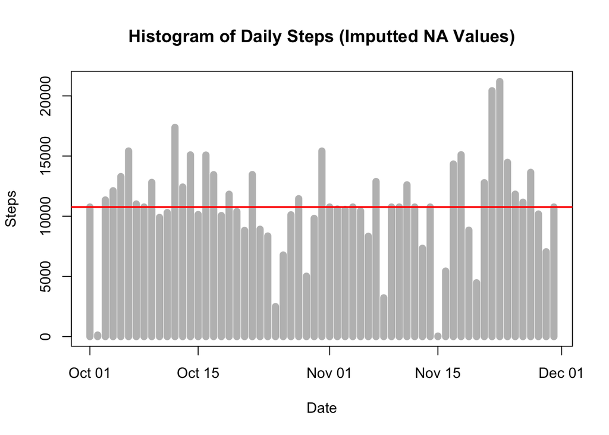

```r
#
total.imputed.steps <- tapply(activity.imputed$steps, activity.imputed$date, sum, na.rm=TRUE)
total.imputed.date <- unique(activity.imputed$date)

plot(total.imputed.date, total.imputed.steps, type="h",
     main="Histogram of Daily Steps (Imputted NA Values)",
     xlab="Date", ylab="Steps", col="grey", lwd=8)
abline(h=mean(total.imputed.steps), col="red", lwd=2)
```

Do these values differ from the estimates from the first part of the assignment? What is the impact of imputing missing data on the estimates of the total daily number of steps?

There appears to be a 15% differential between the calculated mean values for the missing and imputed data sets. There is a 3% differential in the calculated median values for the missing and imputed datasets.

```r
paste("Mean for daily steps =", mean(total.imputed.steps))
```

```
## [1] "Mean for daily steps = 10766.1886792453"
```

```r
paste("Median for daily steps =", median(total.imputed.steps))
```

```
## [1] "Median for daily steps = 10766.1886792453"
```

## ## Are there differences in activity patterns between weekdays and weekends?

Use the dataset with the filled-in missing values to determine if there is a difference in the activities between the weekdays and weekends.

```r
# For loop to create new column called "dayOfWeek" and insert whether each date corresponds to a weekday or weekend
df = data.frame(activity.imputed)

dow <- function(x) {
  if (weekdays(x) %in% c("Saturday", "Sunday")) "weekend" else "weekday"
}
df$dayOfWeek <- sapply(df$date, dow)

# Next, we need to process the data for our needs
interval.week.steps <- df %>%
  group_by(interval, dayOfWeek) %>% summarise(steps = mean(steps))

# Set up the combined plot
interval.plot <- ggplot(interval.week.steps,
                        aes(x=interval, y=steps, color = dayOfWeek)) +
                        geom_line() +
                        facet_wrap(~dayOfWeek, ncol = 1, nrow=2)

#print(interval.plot)
```

[output not shown]